```python
from IPython.display import HTML

HTML('''
<script src='//code.jquery.com/jquery-3.3.1.min.js'></script>
<script>
code_show=true;
function code_toggle() {
if (code_show){
$('div.input').hide();
$('div .jp-CodeCell .jp-Cell-inputWrapper').hide();
} else {
$('div.input').show();
$('div .jp-CodeCell .jp-Cell-inputWrapper').show();
}
code_show = !code_show
}
$( document ).ready(code_toggle);
</script>
<form action="javascript:code_toggle()"><input type="submit" value="Code on/off"></form>''')
```

# Social Determinants of Students in New York City Schools and Effects on Specialized High School Admissions

## Ethan Chan ecc4001

https://github.com/conquer891/DSI_FinalProject

## Introduction and Background

The specialized high schools in New York City (NYC) are a group of selective high schools administered by the NYC Department of Education. The founding three science schools, Stuyvesant High School, The Bronx Science High School of Science, and Brooklyn Technical High School were designated their specialized status in 1972, as a result of the Hecht-Calandra Act. The Hecht-Calandra Act established and preserved the founding schools’ statuses as specialized high schools in science and math for NYC. A uniform exam in mathematics and English, The Specialized High Schools Admissions Test (SHSAT), is administered to all eighth and ninth grade students who opt-in. The test is administered each year in October and November, and students are notified of their results the following March. Students must rank the schools they wish to apply to on the day of the exam. Admission is granted based on overall score results and school preference until there are no remaining seats. In the early 2000s, additional schools were added to the ranks, bringing the total number of specialized high schools to eight.

Throughout the years, there have been many attempts at both the city and state level to change the admissions criteria to these schools. These efforts have largely been unsuccessful. However, due to the plummeting number of black and Hispanic students admitted to the schools in recent years, the issue has once again entered the spotlight. Mayor Bill de Blasio, in addition to the city’s teachers union, the United Federation of Teachers (UFT), have championed overhauling the admissions policy from a single test score to multiple measures which include socioeconomic index, race, and school performance.

Black and Hispanic students make up nearly 70 percent of NYC’s public school system, but just over 10 percent of students admitted into the city’s eight specialized high schools were black or Hispanic. In 2018, over 27,500 students took the admissions exam, 5,500 of which were black. Additionally, of the 4,800 students who were admitted into the specialized schools, only 190 students were black. The overall diversity of the specialized high schools (as of the 2017-2018 school year) paints a jarring picture. Black students make up 4.2% of the total seats, while Hispanics make up 6.1% of the specialized high school population. In contrast, Asian and White students make up 62% and 24.1% of the total number of seats, respectively.

This widening racial disparity requires further analysis. The aim of this project is to explore the factors which may play a role in the specialized high school admissions results.

## Research Questions

1. What are the demographic and socioeconomic makeup of middle schools across New York City?
2. How do the social determinants and academic measures of students in NYC schools affect placement into specialized high schools?
3. How can we employ unsupervised learning to determine which schools in NYC require the most assistance in order to increase specialized high school admissions?

## Methods

This project made use of the PASSNYC School Explorer dataset published by PASSNYC. PASSNYC is a not-for-profit organization that is dedicated to broadening educational opportunities for NYC’s underserved students. The School Explorer dataset contains demographic, socioeconomic and academic measures for all elementary and middle schools in NYC for the year 2016. The PASSNYC dataset was joined with the 2016-2017 SHSAT Admissions Test Offers by Sending School dataset, published by NYC Open Data, to analyze how social determinants of middle schools affect placement into the specialized high schools.

All analyses and visualization were performed exclusively in Python. The libraries used included: Pandas, NumPy, Seaborn, Matplotlib, and Scikit-learn.

The PASSNYC School Explorer dataset contains demographic, socioeconomic, and academic measures of each elementary and middle school in NYC for the year 2016. Upon loading in the dataset and performing some exploratory analysis, it was clear that this dataset required significant cleaning and preprocessing before further analysis could be done. A substantial number of measurement variables were recorded as objects or strings. Variables recorded as percentages included the symbol “%” in each observation, thus necessitating both the “replace” and “astype” functions to remove extraneous symbols and then subsequently converting the entire column to a float data type for further quantitative analysis. Additionally, a key variable of interest, “School Income Estimate” was recorded with dollar and “,” symbols, and recorded as an object data type. These symbols were removed and “School Income Estimate” was then subsequently converted to a float data type.

The PASSNYC School Explorer dataset also contained a considerable amount of missing data. Once the key measurement variables of interest were identified, imputation was performed based on the means of corresponding non-missing data. For example, schools which were missing school income estimates were imputed with the mean income of the corresponding zip code in which the school was located. This imputation was performed on all of the continuous and measurement variables of interest.

The 2016-2017 SHSAT Admissions Test Offers by Sending School dataset contains the recorded number of offers of admissions to specialized high schools in NYC, by school. Interestingly, schools with the lowest number of offers of admissions to specialized high schools were not recorded with a discrete count, but a range of “0-5” students. All “0-5” values were averaged (2.5), and then rounded up to 3 students as it is not possible to send 2.5 students to a specialized high school. Both the PASSNYC School Explorer and 2016-2017 SHSAT Admissions Test Offers by Sending School datasets contained DBN codes for each corresponding school. The DBN code is a unique code assigned to every school in NYC.

Both datasets were joined together on the DBN codes. A left join was performed, with the 2016-2017 SHSAT Admissions Test Offers by Sending School dataset on the left. Merging the two datasets together performed a very useful function. As we are only interested in NYC schools that can potentially send students to specialized high schools, the merging of the datasets effectively removed any schools that do not offer the eighth or ninth grades.

Several methods of data visualization, including bar charts, scatter, and regression plots were utilized in order to tell a cohesive story about how social determinants of schools affect placement into specialized high schools. A correlation matrix of key variables was used in order to determine which variables had the strongest associations with the number of offers to specialized high schools.

K-means clustering was performed on English Literature Arts (ELA) and math proficiency data to identify clusters of schools which need the most assistance. The SHSAT exam tests exclusively tests on English and mathematical aptitude, therefore it was logical to perform K-means clustering on the two variables above.

```python
import pandas as pd
pd.options.display.max_columns = None
import numpy as np
import seaborn as sns
import matplotlib.pyplot as plt
from matplotlib import cm
import matplotlib as mpl
from sklearn.preprocessing import StandardScaler
from sklearn.cluster import KMeans

import warnings
warnings.filterwarnings('ignore')
```

```python
#Reading in PASSNYC dataset
schools = pd.read_csv("C:/Users/16462/OneDrive/Documents/Weill Cornell/Data Science I/Final/2016 School Explorer.csv")
```

```python
schools.head()
```

|  | Adjusted Grade | New? | Other Location Code in LCGMS | School Name | SED Code | Location Code | District | Latitude | Longitude | Address (Full) | City | Zip | Grades | Grade Low | Grade High | Community School? | Economic Need Index | School Income Estimate | Percent ELL | Percent Asian | Percent Black | Percent Hispanic | Percent Black / Hispanic | Percent White | Student Attendance Rate | Percent of Students Chronically Absent | Rigorous Instruction % | Rigorous Instruction Rating | Collaborative Teachers % | … |
| --- | --- | --- | --- | --- | --- | --- | --- | --- | --- | --- | --- | --- | --- | --- | --- | --- | --- | --- | --- | --- | --- | --- | --- | --- | --- | --- | --- | --- | --- | --- |
| 0 | NaN | NaN | NaN | P.S. 015 ROBERTO CLEMENTE | 3.101000e+11 | 01M015 | 1 | 40.721834 | -73.978766 | 333 E 4TH ST NEW YORK, NY 10009 | NEW YORK | 10009 | PK,0K,01,02,03,04,05 | PK | 5 | Yes | 0.919 | $31,141.72 | 9% | 5% | 32% | 60% | 92% | 1% | 94% | 18% | 89% | Meeting Target | 94% | … |
| 1 | NaN | NaN | NaN | P.S. 019 ASHER LEVY | 3.101000e+11 | 01M019 | 1 | 40.729892 | -73.984231 | 185 1ST AVE NEW YORK, NY 10003 | NEW YORK | 10003 | PK,0K,01,02,03,04,05 | PK | 5 | No | 0.641 | $56,462.88 | 5% | 10% | 20% | 63% | 83% | 6% | 92% | 30% | 96% | NaN | 96% | … |
| 2 | NaN | NaN | NaN | P.S. 020 ANNA SILVER | 3.101000e+11 | 01M020 | 1 | 40.721274 | -73.986315 | 166 ESSEX ST NEW YORK, NY 10002 | NEW YORK | 10002 | PK,0K,01,02,03,04,05 | PK | 5 | No | 0.744 | $44,342.61 | 15% | 35% | 8% | 49% | 57% | 4% | 94% | 20% | 87% | Meeting Target | 77% | … |
| 3 | NaN | NaN | NaN | P.S. 034 FRANKLIN D. ROOSEVELT | 3.101000e+11 | 01M034 | 1 | 40.726147 | -73.975043 | 730 E 12TH ST NEW YORK, NY 10009 | NEW YORK | 10009 | PK,0K,01,02,03,04,05,06,07,08 | PK | 8 | No | 0.860 | $31,454.00 | 7% | 5% | 29% | 63% | 92% | 4% | 92% | 28% | 85% | Approaching Target | 78% | … |
| 4 | NaN | NaN | NaN | THE STAR ACADEMY - P.S.63 | 3.101000e+11 | 01M063 | 1 | 40.724404 | -73.986360 | 121 E 3RD ST NEW YORK, NY 10009 | NEW YORK | 10009 | PK,0K,01,02,03,04,05 | PK | 5 | No | 0.730 | $46,435.59 | 3% | 4% | 20% | 65% | 84% | 10% | 93% | 23% | 90% | Meeting Target | 88% | … |

```python
schools.shape

#We have information on 1272 elementary and middle schools in NYC
```

```
(1272, 161)
```

```python
#We have information on 1272 schools in NYC
```

```python
schools.describe()
```

|  | SED Code | District | Latitude | Longitude | Zip | Economic Need Index | Average ELA Proficiency | Average Math Proficiency | Grade 3 ELA - All Students Tested | Grade 3 ELA 4s - All Students | Grade 3 ELA 4s - American Indian or Alaska Native | Grade 3 ELA 4s - Black or African American | Grade 3 ELA 4s - Hispanic or Latino | Grade 3 ELA 4s - Asian or Pacific Islander | Grade 3 ELA 4s - White | Grade 3 ELA 4s - Multiracial | Grade 3 ELA 4s - Limited English Proficient | Grade 3 ELA 4s - Economically Disadvantaged | Grade 3 Math - All Students tested | Grade 3 Math 4s - All Students | Grade 3 Math 4s - American Indian or Alaska Native | Grade 3 Math 4s - Black or African American | Grade 3 Math 4s - Hispanic or Latino | Grade 3 Math 4s - Asian or Pacific Islander | Grade 3 Math 4s - White | Grade 3 Math 4s - Multiracial | Grade 3 Math 4s - Limited English Proficient | Grade 3 Math 4s - Economically Disadvantaged | Grade 4 ELA - All Students Tested | … |
| --- | --- | --- | --- | --- | --- | --- | --- | --- | --- | --- | --- | --- | --- | --- | --- | --- | --- | --- | --- | --- | --- | --- | --- | --- | --- | --- | --- | --- | --- | --- |
| count | 1.272000e+03 | 1272.00000 | 1272.000000 | 1272.000000 | 1272.000000 | 1247.000000 | 1217.000000 | 1217.000000 | 1272.000000 | 1272.000000 | 1272.000000 | 1272.000000 | 1272.000000 | 1272.000000 | 1272.000000 | 1272.000000 | 1272.000000 | 1272.000000 | 1272.000000 | 1272.000000 | 1272.000000 | 1272.000000 | 1272.000000 | 1272.000000 | 1272.000000 | 1272.000000 | 1272.000000 | 1272.000000 | 1272.000000 | … |
| mean | 3.286698e+11 | 16.13522 | 40.734537 | -73.918347 | 10815.720912 | 0.672281 | 2.534215 | 2.668956 | 60.569182 | 4.952830 | 0.009434 | 0.713836 | 0.828616 | 1.347484 | 1.370283 | 0.039308 | 0.024371 | 1.982704 | 61.651730 | 13.878145 | 0.027516 | 2.255503 | 2.815252 | 4.025943 | 3.010220 | 0.066038 | 0.530660 | 6.677673 | 58.007862 | … |
| std | 1.222021e+10 | 9.24527 | 0.086602 | 0.080576 | 529.588875 | 0.210959 | 0.363589 | 0.470470 | 57.872496 | 8.300568 | 0.148124 | 2.272858 | 1.839046 | 4.113688 | 4.096073 | 0.352617 | 0.182311 | 3.738251 | 59.211955 | 20.003778 | 0.266157 | 7.041183 | 5.408097 | 11.844061 | 8.294485 | 0.557089 | 2.181534 | 11.261356 | 57.186321 | … |
| min | 3.075000e+11 | 1.00000 | 40.507803 | -74.244025 | 10001.000000 | 0.049000 | 1.810000 | 1.830000 | 0.000000 | 0.000000 | 0.000000 | 0.000000 | 0.000000 | 0.000000 | 0.000000 | 0.000000 | 0.000000 | 0.000000 | 0.000000 | 0.000000 | 0.000000 | 0.000000 | 0.000000 | 0.000000 | 0.000000 | 0.000000 | 0.000000 | 0.000000 | 0.000000 | … |
| 25% | 3.208752e+11 | 9.00000 | 40.669499 | -73.957057 | 10452.000000 | 0.550000 | 2.250000 | 2.300000 | 0.000000 | 0.000000 | 0.000000 | 0.000000 | 0.000000 | 0.000000 | 0.000000 | 0.000000 | 0.000000 | 0.000000 | 0.000000 | 0.000000 | 0.000000 | 0.000000 | 0.000000 | 0.000000 | 0.000000 | 0.000000 | 0.000000 | 0.000000 | 0.000000 | … |
| 50% | 3.315005e+11 | 15.00000 | 40.722995 | -73.920571 | 11203.000000 | 0.731000 | 2.450000 | 2.580000 | 54.000000 | 1.000000 | 0.000000 | 0.000000 | 0.000000 | 0.000000 | 0.000000 | 0.000000 | 0.000000 | 0.000000 | 55.000000 | 5.000000 | 0.000000 | 0.000000 | 0.000000 | 0.000000 | 0.000000 | 0.000000 | 0.000000 | 1.000000 | 52.000000 | … |
| 75% | 3.424000e+11 | 24.00000 | 40.815632 | -73.879264 | 11232.000000 | 0.841000 | 2.760000 | 2.980000 | 94.000000 | 7.000000 | 0.000000 | 0.000000 | 1.000000 | 0.000000 | 0.000000 | 0.000000 | 0.000000 | 2.000000 | 96.000000 | 20.000000 | 0.000000 | 1.000000 | 3.000000 | 0.000000 | 0.000000 | 0.000000 | 0.000000 | 9.000000 | 92.000000 | … |
| max | 3.531010e+11 | 32.00000 | 40.903455 | -73.708920 | 11694.000000 | 0.957000 | 3.930000 | 4.200000 | 356.000000 | 55.000000 | 3.000000 | 24.000000 | 20.000000 | 39.000000 | 37.000000 | 5.000000 | 3.000000 | 29.000000 | 365.000000 | 130.000000 | 4.000000 | 67.000000 | 41.000000 | 110.000000 | 65.000000 | 8.000000 | 39.000000 | 98.000000 | 330.000000 | … |

```python
print(schools.dtypes)

#Identifying data types of each column in PASSNYC dataset. Many of the variables are stored as objects!
```

```
Adjusted Grade                                         object
New?                                                   object
Other Location Code in LCGMS                           object
School Name                                            object
SED Code                                              float64
Location Code                                          object
District                                                int64
Latitude                                              float64
Longitude                                             float64
Address (Full)                                         object
City                                                   object
Zip                                                     int64
Grades                                                 object
Grade Low                                              object
Grade High                                             object
Community School?                                      object
Economic Need Index                                   float64
School Income Estimate                                 object
Percent ELL                                            object
Percent Asian                                          object
Percent Black                                          object
Percent Hispanic                                       object
Percent Black / Hispanic                               object
Percent White                                          object
Student Attendance Rate                                object
Percent of Students Chronically Absent                 object
Rigorous Instruction %                                 object
Rigorous Instruction Rating                            object
Collaborative Teachers %                               object
Collaborative Teachers Rating                          object
                                                       ...
Grade 7 Math - All Students Tested                      int64
Grade 7 Math 4s - All Students                          int64
Grade 7 Math 4s - American Indian or Alaska Native      int64
Grade 7 Math 4s - Black or African American             int64
Grade 7 Math 4s - Hispanic or Latino                    int64
Grade 7 Math 4s - Asian or Pacific Islander             int64
Grade 7 Math 4s - White                                 int64
Grade 7 Math 4s - Multiracial                           int64
Grade 7 Math 4s - Limited English Proficient            int64
Grade 7 Math 4s - Economically Disadvantaged            int64
Grade 8 ELA - All Students Tested                       int64
Grade 8 ELA 4s - All Students                           int64
Grade 8 ELA 4s - American Indian or Alaska Native       int64
Grade 8 ELA 4s - Black or African American              int64
Grade 8 ELA 4s - Hispanic or Latino                     int64
Grade 8 ELA 4s - Asian or Pacific Islander              int64
Grade 8 ELA 4s - White                                  int64
Grade 8 ELA 4s - Multiracial                            int64
Grade 8 ELA 4s - Limited English Proficient             int64
Grade 8 ELA 4s - Economically Disadvantaged             int64
Grade 8 Math - All Students Tested                      int64
Grade 8 Math 4s - All Students                          int64
Grade 8 Math 4s - American Indian or Alaska Native      int64
Grade 8 Math 4s - Black or African American             int64
Grade 8 Math 4s - Hispanic or Latino                    int64
Grade 8 Math 4s - Asian or Pacific Islander             int64
Grade 8 Math 4s - White                                 int64
Grade 8 Math 4s - Multiracial                           int64
Grade 8 Math 4s - Limited English Proficient            int64
Grade 8 Math 4s - Economically Disadvantaged            int64
Length: 161, dtype: object
```

```python
schools.isnull().sum().sort_values(ascending=False) #checking for missing values
```

```
Other Location Code in LCGMS                          1271
Adjusted Grade                                        1270
New?                                                  1245
School Income Estimate                                 396
Student Achievement Rating                              86
Supportive Environment Rating                           80
Collaborative Teachers Rating                           76
Rigorous Instruction Rating                             76
Trust Rating                                            73
Strong Family-Community Ties Rating                     73
Effective School Leadership Rating                      73
Average Math Proficiency                                55
Average ELA Proficiency                                 55
Strong Family-Community Ties %                          25
Student Attendance Rate                                 25
Trust %                                                 25
Effective School Leadership %                           25
Economic Need Index                                     25
Supportive Environment %                                25
Collaborative Teachers %                                25
Rigorous Instruction %                                  25
Percent of Students Chronically Absent                  25
Grade 4 ELA 4s - American Indian or Alaska Native        0
Grade 4 ELA 4s - All Students                            0
Grade 4 ELA - All Students Tested                        0
Grades                                                   0
Grade 4 ELA 4s - Black or African American               0
Grade 3 Math 4s - Limited English Proficient             0
Grade 3 Math 4s - Multiracial                            0
Grade 3 Math 4s - White                                  0
                                                      ...
Grade 5 ELA 4s - Limited English Proficient              0
Grade 5 Math 4s - Limited English Proficient             0
Grade 5 ELA 4s - Multiracial                             0
Grade 5 ELA 4s - White                                   0
Grade 5 ELA 4s - Asian or Pacific Islander               0
Grade 5 ELA 4s - Hispanic or Latino                      0
Grade 5 ELA 4s - Black or African American               0
Grade 5 ELA 4s - American Indian or Alaska Native        0
Grade 5 ELA 4s - All Students                            0
Grade 5 Math 4s - Multiracial                            0
Grade 5 Math 4s - Economically Disadvantaged             0
Grade 6 Math 4s - Multiracial                            0
Grade 6 ELA 4s - Economically Disadvantaged              0
Grade 6 Math 4s - White                                  0
Grade 6 Math 4s - Asian or Pacific Islander              0
Grade 6 Math 4s - Hispanic or Latino                     0
Grade 6 Math 4s - Black or African American              0
Grade 6 Math 4s - American Indian or Alaska Native       0
Grade 6 Math 4s - All Students                           0
Grade 6 Math - All Students Tested                       0
Grade 6 ELA 4s - Limited English Proficient              0
Grade 6 ELA - All Students Tested                        0
Grade 6 ELA 4s - Multiracial                             0
Grade 6 ELA 4s - White                                   0
Grade 6 ELA 4s - Asian or Pacific Islander               0
Grade 6 ELA 4s - Hispanic or Latino                      0
Grade 6 ELA 4s - Black or African American               0
Grade 6 ELA 4s - American Indian or Alaska Native        0
Grade 6 ELA 4s - All Students                            0
Grade 4 Math 4s - Economically Disadvantaged             0
Length: 161, dtype: int64
```

```python
#Data preprocessing and cleaning!

#Cleaning up dataset/preprocessing variables of interest. Removing '%' from variables of interest and converting to float for analysis.

schools['Percent Black']=schools['Percent Black'].replace({'\%':''},regex=True).astype(float)
schools['Percent White']=schools['Percent White'].replace({'\%':''},regex=True).astype(float)
schools['Percent Asian']=schools['Percent Asian'].replace({'\%':''},regex=True).astype(float)
schools['Percent Hispanic']=schools['Percent Hispanic'].replace({'\%':''},regex=True).astype(float)
schools['Percent Black / Hispanic']=schools['Percent Black / Hispanic'].replace({'\%':''},regex=True).astype(float)
schools['Student Attendance Rate']=schools['Student Attendance Rate'].replace({'\%':''},regex=True).astype(float)
schools['Percent of Students Chronically Absent']=schools['Percent of Students Chronically Absent'].replace({'\%':''},regex=True).astype(float)
schools['Rigorous Instruction %']=schools['Rigorous Instruction %'].replace({'\%':''},regex=True).astype(float)
schools['Percent ELL']=schools['Percent ELL'].replace({'\%':''},regex=True).astype(float)
schools['Collaborative Teachers %']=schools['Collaborative Teachers %'].replace({'\%':''},regex=True).astype(float)
schools['Supportive Environment %']=schools['Supportive Environment %'].replace({'\%':''},regex=True).astype(float)
schools['Effective School Leadership %']=schools['Effective School Leadership %'].replace({'\%':''},regex=True).astype(float)
schools['Strong Family-Community Ties %']=schools['Strong Family-Community Ties %'].replace({'\%':''},regex=True).astype(float)
schools['Trust %']=schools['Trust %'].replace({'\%':''},regex=True).astype(float)
```

```python
schools['School Income Estimate'] = schools['School Income Estimate'].replace({'\$': '', ',': ''}, regex=True).astype(float)
#Replacing '$' and ',' in income estimate and formatting as float.
```

```python
schools.head()
```

|  | Adjusted Grade | New? | Other Location Code in LCGMS | School Name | SED Code | Location Code | District | Latitude | Longitude | Address (Full) | City | Zip | Grades | Grade Low | Grade High | Community School? | Economic Need Index | School Income Estimate | Percent ELL | Percent Asian | Percent Black | Percent Hispanic | Percent Black / Hispanic | Percent White | Student Attendance Rate | Percent of Students Chronically Absent | Rigorous Instruction % | Rigorous Instruction Rating | Collaborative Teachers % | … |
| --- | --- | --- | --- | --- | --- | --- | --- | --- | --- | --- | --- | --- | --- | --- | --- | --- | --- | --- | --- | --- | --- | --- | --- | --- | --- | --- | --- | --- | --- | --- |
| 0 | NaN | NaN | NaN | P.S. 015 ROBERTO CLEMENTE | 3.101000e+11 | 01M015 | 1 | 40.721834 | -73.978766 | 333 E 4TH ST NEW YORK, NY 10009 | NEW YORK | 10009 | PK,0K,01,02,03,04,05 | PK | 5 | Yes | 0.919 | 31141.72 | 9.0 | 5.0 | 32.0 | 60.0 | 92.0 | 1.0 | 94.0 | 18.0 | 89.0 | Meeting Target | 94.0 | … |
| 1 | NaN | NaN | NaN | P.S. 019 ASHER LEVY | 3.101000e+11 | 01M019 | 1 | 40.729892 | -73.984231 | 185 1ST AVE NEW YORK, NY 10003 | NEW YORK | 10003 | PK,0K,01,02,03,04,05 | PK | 5 | No | 0.641 | 56462.88 | 5.0 | 10.0 | 20.0 | 63.0 | 83.0 | 6.0 | 92.0 | 30.0 | 96.0 | NaN | 96.0 | … |
| 2 | NaN | NaN | NaN | P.S. 020 ANNA SILVER | 3.101000e+11 | 01M020 | 1 | 40.721274 | -73.986315 | 166 ESSEX ST NEW YORK, NY 10002 | NEW YORK | 10002 | PK,0K,01,02,03,04,05 | PK | 5 | No | 0.744 | 44342.61 | 15.0 | 35.0 | 8.0 | 49.0 | 57.0 | 4.0 | 94.0 | 20.0 | 87.0 | Meeting Target | 77.0 | … |
| 3 | NaN | NaN | NaN | P.S. 034 FRANKLIN D. ROOSEVELT | 3.101000e+11 | 01M034 | 1 | 40.726147 | -73.975043 | 730 E 12TH ST NEW YORK, NY 10009 | NEW YORK | 10009 | PK,0K,01,02,03,04,05,06,07,08 | PK | 8 | No | 0.860 | 31454.00 | 7.0 | 5.0 | 29.0 | 63.0 | 92.0 | 4.0 | 92.0 | 28.0 | 85.0 | Approaching Target | 78.0 | … |
| 4 | NaN | NaN | NaN | THE STAR ACADEMY - P.S.63 | 3.101000e+11 | 01M063 | 1 | 40.724404 | -73.986360 | 121 E 3RD ST NEW YORK, NY 10009 | NEW YORK | 10009 | PK,0K,01,02,03,04,05 | PK | 5 | No | 0.730 | 46435.59 | 3.0 | 4.0 | 20.0 | 65.0 | 84.0 | 10.0 | 93.0 | 23.0 | 90.0 | Meeting Target | 88.0 | … |

```python
#We will be imputing missing values in our variables of interest by using the average of the corresponding Zip code
schools['School Income Estimate'] = schools['School Income Estimate'].fillna(schools.groupby('Zip')['School Income Estimate'].transform('mean'))
schools['School Income Estimate'] = schools['School Income Estimate'].fillna(schools['School Income Estimate'].mean())

schools['Rigorous Instruction %'] = schools['Rigorous Instruction %'].fillna(schools.groupby('Zip')['Rigorous Instruction %'].transform('mean'))
schools['Rigorous Instruction %'] = schools['Rigorous Instruction %'].fillna(schools['Rigorous Instruction %'].mean())

schools['Average Math Proficiency'] = schools['Average Math Proficiency'].fillna(schools.groupby('Zip')['Average Math Proficiency'].transform('mean'))
schools['Average Math Proficiency'] = schools['Average Math Proficiency'].fillna(schools['Average Math Proficiency'].mean())

schools['Average ELA Proficiency'] = schools['Average ELA Proficiency'].fillna(schools.groupby('Zip')['Average ELA Proficiency'].transform('mean'))
schools['Average ELA Proficiency'] = schools['Average ELA Proficiency'].fillna(schools['Average ELA Proficiency'].mean())

schools['Economic Need Index'] = schools['Economic Need Index'].fillna(schools.groupby('Zip')['Economic Need Index'].transform('mean'))
schools['Economic Need Index'] = schools['Economic Need Index'].fillna(schools['Economic Need Index'].mean())

schools['Percent of Students Chronically Absent'] = schools['Percent of Students Chronically Absent'].fillna(schools.groupby('Zip')['Percent of Students Chronically Absent'].transform('mean'))
schools['Percent of Students Chronically Absent'] = schools['Percent of Students Chronically Absent'].fillna(schools['Percent of Students Chronically Absent'].mean())

schools['Supportive Environment %'] = schools['Supportive Environment %'].fillna(schools.groupby('Zip')['Supportive Environment %'].transform('mean'))
schools['Supportive Environment %'] = schools['Supportive Environment %'].fillna(schools['Supportive Environment %'].mean())

schools['Collaborative Teachers %'] = schools['Collaborative Teachers %'].fillna(schools.groupby('Zip')['Collaborative Teachers %'].transform('mean'))
schools['Collaborative Teachers %'] = schools['Collaborative Teachers %'].fillna(schools['Collaborative Teachers %'].mean())

schools['Trust %'] = schools['Trust %'].fillna(schools.groupby('Zip')['Trust %'].transform('mean'))
schools['Trust %'] = schools['Trust %'].fillna(schools['Trust %'].mean())

schools['Effective School Leadership %'] = schools['Effective School Leadership %'].fillna(schools.groupby('Zip')['Effective School Leadership %'].transform('mean'))
schools['Effective School Leadership %'] = schools['Effective School Leadership %'].fillna(schools['Effective School Leadership %'].mean())

schools['Strong Family-Community Ties %'] = schools['Strong Family-Community Ties %'].fillna(schools.groupby('Zip')['Strong Family-Community Ties %'].transform('mean'))
schools['Strong Family-Community Ties %'] = schools['Strong Family-Community Ties %'].fillna(schools['Strong Family-Community Ties %'].mean())

schools['Student Attendance Rate'] = schools['Student Attendance Rate'].fillna(schools.groupby('Zip')['Student Attendance Rate'].transform('mean'))
schools['Student Attendance Rate'] = schools['Student Attendance Rate'].fillna(schools['Student Attendance Rate'].mean())
```

```python
schools.isnull().sum().sort_values(ascending=False)
```

```
Other Location Code in LCGMS                          1271
Adjusted Grade                                        1270
New?                                                  1245
Student Achievement Rating                              86
Supportive Environment Rating                           80
Rigorous Instruction Rating                             76
Collaborative Teachers Rating                           76
Trust Rating                                            73
Strong Family-Community Ties Rating                     73
Effective School Leadership Rating                      73
Grade 3 Math 4s - All Students                           0
Grade 3 Math 4s - Asian or Pacific Islander              0
Grade 3 Math 4s - Hispanic or Latino                     0
Grade 3 Math 4s - Black or African American              0
Grade 3 Math 4s - American Indian or Alaska Native       0
Grade 3 ELA 4s - Economically Disadvantaged              0
Grade 3 Math - All Students tested                       0
Grade 3 Math 4s - Multiracial                            0
Grade 3 ELA 4s - Limited English Proficient              0
Grade 3 ELA 4s - Multiracial                             0
Grade 3 ELA 4s - White                                   0
Grade 3 ELA 4s - Asian or Pacific Islander               0
Grade 3 Math 4s - White                                  0
Grade 3 Math 4s - Limited English Proficient             0
Grade 3 ELA 4s - Black or African American               0
Grade 3 Math 4s - Economically Disadvantaged             0
Grade 4 Math 4s - White                                  0
Grade 4 Math 4s - Asian or Pacific Islander              0
Grade 4 Math 4s - Hispanic or Latino                     0
Grade 4 Math 4s - Black or African American              0
                                                      ...
Grade 5 ELA 4s - Limited English Proficient              0
Grade 5 Math 4s - Limited English Proficient             0
Grade 5 ELA 4s - Multiracial                             0
Grade 5 ELA 4s - White                                   0
Grade 5 ELA 4s - Asian or Pacific Islander               0
Grade 5 ELA 4s - Hispanic or Latino                      0
Grade 5 ELA 4s - Black or African American               0
Grade 5 ELA 4s - American Indian or Alaska Native        0
Grade 5 ELA 4s - All Students                            0
Grade 5 Math 4s - Multiracial                            0
Grade 5 Math 4s - Economically Disadvantaged             0
Grade 6 Math 4s - Multiracial                            0
Grade 6 ELA 4s - Economically Disadvantaged              0
Grade 6 Math 4s - White                                  0
Grade 6 Math 4s - Asian or Pacific Islander              0
Grade 6 Math 4s - Hispanic or Latino                     0
Grade 6 Math 4s - Black or African American              0
Grade 6 Math 4s - American Indian or Alaska Native       0
Grade 6 Math 4s - All Students                           0
Grade 6 Math - All Students Tested                       0
Grade 6 ELA 4s - Limited English Proficient              0
Grade 6 ELA - All Students Tested                        0
Grade 6 ELA 4s - Multiracial                             0
Grade 6 ELA 4s - White                                   0
Grade 6 ELA 4s - Asian or Pacific Islander               0
Grade 6 ELA 4s - Hispanic or Latino                      0
Grade 6 ELA 4s - Black or African American               0
Grade 6 ELA 4s - American Indian or Alaska Native        0
Grade 6 ELA 4s - All Students                            0
Grade 4 Math 4s - Economically Disadvantaged             0
Length: 161, dtype: int64
```

```python
offers = pd.read_csv("C:/Users/16462/OneDrive/Documents/Weill Cornell/Data Science I/Final/2016-2017_SHSAT_Admissions_Test_Offers_By_Sending_School.csv")

#Reading in offers of 2016-2017 offers of admission from Open NYC
```

```python
offers.head()
```

|  | Feeder School DBN | Feeder School Name | Count of Students in HS Admissions | Count of Testers | Count of Offers |
| --- | --- | --- | --- | --- | --- |
| 0 | 01M034 | P.S. 034 FRANKLIN D. ROOSEVELT | 61.0 | 10 | 0-5 |
| 1 | 01M140 | P.S. 140 NATHAN STRAUS | 59.0 | 10 | 0-5 |
| 2 | 01M184 | P.S. 184M SHUANG WEN | 80.0 | 64 | 28 |
| 3 | 01M188 | P.S. 188 THE ISLAND SCHOOL | 60.0 | 11 | 0-5 |
| 4 | 01M301 | TECHNOLOGY, ARTS, AND SCIENCES STUDIO | 58.0 | 10 | 0-5 |

```python
offers.shape
#We have data on 594 feeder schoools.
```

```
(594, 5)
```

```python
merged = pd.merge(left = offers, right = schools, left_on = 'Feeder School DBN', right_on = 'Location Code', how = 'left')

#We performed a left join above, with the "offers" dataset on the left. This effectively removes the schools that don't offer up to the 8th grade from the "schools" dataset, since only 8th and 9th graders are eligible to take the SSHAT exam. We joined the data on the DBN school code that exists in both datasets.
```

```python
merged.head()
```

|  | Feeder School DBN | Feeder School Name | Count of Students in HS Admissions | Count of Testers | Count of Offers | Adjusted Grade | New? | Other Location Code in LCGMS | School Name | SED Code | Location Code | District | Latitude | Longitude | Address (Full) | City | Zip | Grades | Grade Low | Grade High | Community School? | Economic Need Index | School Income Estimate | Percent ELL | Percent Asian | Percent Black | Percent Hispanic | Percent Black / Hispanic | Percent White | … |
| --- | --- | --- | --- | --- | --- | --- | --- | --- | --- | --- | --- | --- | --- | --- | --- | --- | --- | --- | --- | --- | --- | --- | --- | --- | --- | --- | --- | --- | --- | --- |
| 0 | 01M034 | P.S. 034 FRANKLIN D. ROOSEVELT | 61.0 | 10 | 0-5 | NaN | NaN | NaN | P.S. 034 FRANKLIN D. ROOSEVELT | 3.101000e+11 | 01M034 | 1.0 | 40.726147 | -73.975043 | 730 E 12TH ST NEW YORK, NY 10009 | NEW YORK | 10009.0 | PK,0K,01,02,03,04,05,06,07,08 | PK | 8 | No | 0.860 | 31454.00 | 7.0 | 5.0 | 29.0 | 63.0 | 92.0 | 4.0 | … |
| 1 | 01M140 | P.S. 140 NATHAN STRAUS | 59.0 | 10 | 0-5 | NaN | NaN | NaN | P.S. 140 NATHAN STRAUS | 3.101000e+11 | 01M140 | 1.0 | 40.719128 | -73.983283 | 123 RIDGE ST NEW YORK, NY 10002 | NEW YORK | 10002.0 | PK,0K,01,02,03,04,05,06,07,08 | PK | 8 | No | 0.849 | 34889.24 | 14.0 | 5.0 | 13.0 | 78.0 | 90.0 | 3.0 | … |
| 2 | 01M184 | P.S. 184M SHUANG WEN | 80.0 | 64 | 28 | NaN | NaN | NaN | P.S. 184M SHUANG WEN | 3.101000e+11 | 01M184 | 1.0 | 40.711437 | -73.985486 | 327 CHERRY ST-2ND FL NEW YORK, NY 10002 | NEW YORK | 10002.0 | PK,0K,01,02,03,04,05,06,07,08 | PK | 8 | No | 0.559 | 40809.90 | 17.0 | 71.0 | 4.0 | 12.0 | 15.0 | 9.0 | … |
| 3 | 01M188 | P.S. 188 THE ISLAND SCHOOL | 60.0 | 11 | 0-5 | NaN | NaN | NaN | P.S. 188 THE ISLAND SCHOOL | 3.101000e+11 | 01M188 | 1.0 | 40.719870 | -73.977376 | 442 E HOUSTON ST NEW YORK, NY 10002 | NEW YORK | 10002.0 | PK,0K,01,02,03,04,05,06,07,08 | PK | 8 | Yes | 0.917 | 27881.59 | 16.0 | 2.0 | 30.0 | 64.0 | 93.0 | 4.0 | … |
| 4 | 01M301 | TECHNOLOGY, ARTS, AND SCIENCES STUDIO | 58.0 | 10 | 0-5 | NaN | NaN | NaN | TECHNOLOGY, ARTS, AND SCIENCES STUDIO | 3.101000e+11 | 01M301 | 1.0 | 40.729892 | -73.984231 | 185 1ST AVE NEW YORK, NY 10003 | NEW YORK | 10003.0 | 06,07,08 | 6 | 8 | No | 0.791 | 75459.24 | 6.0 | 8.0 | 29.0 | 55.0 | 84.0 | 4.0 | … |

```python
merged.shape
```

```
(594, 166)
```

```python
merged[merged['Location Code'].isnull()]

#3 schools did not have a location code in the PASSNYC schools dataset. Let's remove them from our analysis.
```

|  | Feeder School DBN | Feeder School Name | Count of Students in HS Admissions | Count of Testers | Count of Offers | Adjusted Grade | New? | Other Location Code in LCGMS | School Name | SED Code | Location Code | District | Latitude | Longitude | Address (Full) | City | Zip | Grades | Grade Low | Grade High | Community School? | Economic Need Index | School Income Estimate | Percent ELL | Percent Asian | Percent Black | Percent Hispanic | Percent Black / Hispanic | Percent White | … |
| --- | --- | --- | --- | --- | --- | --- | --- | --- | --- | --- | --- | --- | --- | --- | --- | --- | --- | --- | --- | --- | --- | --- | --- | --- | --- | --- | --- | --- | --- | --- |
| 112 | 07X584 | I.S. 584 | NaN | NaN | NaN | NaN | NaN | NaN | NaN | NaN | NaN | NaN | NaN | NaN | NaN | NaN | NaN | NaN | NaN | NaN | NaN | NaN | NaN | NaN | NaN | NaN | NaN | NaN | NaN | … |
| 531 | 84M204 | CAPITAL PREPARATORY (CP) HARLEM CHARTER SCHOOL | NaN | NaN | NaN | NaN | NaN | NaN | NaN | NaN | NaN | NaN | NaN | NaN | NaN | NaN | NaN | NaN | NaN | NaN | NaN | NaN | NaN | NaN | NaN | NaN | NaN | NaN | NaN | … |
| 537 | 84M337 | NEW YORK CENTER FOR AUTISM CHARTER SCHOOL | NaN | 0-5 | 0-5 | NaN | NaN | NaN | NaN | NaN | NaN | NaN | NaN | NaN | NaN | NaN | NaN | NaN | NaN | NaN | NaN | NaN | NaN | NaN | NaN | NaN | NaN | NaN | NaN | … |

```python
merged = merged.dropna(subset=['Location Code']) #Dropping the 3 schools above
```

```python
print(merged.dtypes)
```

```
Feeder School DBN                                      object
Feeder School Name                                     object
Count of Students in HS Admissions                    float64
Count of Testers                                       object
Count of Offers                                        object
Adjusted Grade                                         object
New?                                                   object
Other Location Code in LCGMS                           object
School Name                                            object
SED Code                                              float64
Location Code                                          object
District                                              float64
Latitude                                              float64
Longitude                                             float64
Address (Full)                                         object
City                                                   object
Zip                                                   float64
Grades                                                 object
Grade Low                                              object
Grade High                                             object
Community School?                                      object
Economic Need Index                                   float64
School Income Estimate                                float64
Percent ELL                                           float64
Percent Asian                                         float64
Percent Black                                         float64
Percent Hispanic                                      float64
Percent Black / Hispanic                              float64
Percent White                                         float64
Student Attendance Rate                               float64
                                                       ...
Grade 7 Math - All Students Tested                    float64
Grade 7 Math 4s - All Students                        float64
Grade 7 Math 4s - American Indian or Alaska Native    float64
Grade 7 Math 4s - Black or African American           float64
Grade 7 Math 4s - Hispanic or Latino                  float64
Grade 7 Math 4s - Asian or Pacific Islander           float64
Grade 7 Math 4s - White                               float64
Grade 7 Math 4s - Multiracial                         float64
Grade 7 Math 4s - Limited English Proficient          float64
Grade 7 Math 4s - Economically Disadvantaged          float64
Grade 8 ELA - All Students Tested                     float64
Grade 8 ELA 4s - All Students                         float64
Grade 8 ELA 4s - American Indian or Alaska Native     float64
Grade 8 ELA 4s - Black or African American            float64
Grade 8 ELA 4s - Hispanic or Latino                   float64
Grade 8 ELA 4s - Asian or Pacific Islander            float64
Grade 8 ELA 4s - White                                float64
Grade 8 ELA 4s - Multiracial                          float64
Grade 8 ELA 4s - Limited English Proficient           float64
Grade 8 ELA 4s - Economically Disadvantaged           float64
Grade 8 Math - All Students Tested                    float64
Grade 8 Math 4s - All Students                        float64
Grade 8 Math 4s - American Indian or Alaska Native    float64
Grade 8 Math 4s - Black or African American           float64
Grade 8 Math 4s - Hispanic or Latino                  float64
Grade 8 Math 4s - Asian or Pacific Islander           float64
Grade 8 Math 4s - White                               float64
Grade 8 Math 4s - Multiracial                         float64
Grade 8 Math 4s - Limited English Proficient          float64
Grade 8 Math 4s - Economically Disadvantaged          float64
Length: 166, dtype: object
```

```python
merged.shape
```

```
(591, 166)
```

```python
merged['Percent Asian/White'] = merged['Percent Asian'] + merged['Percent White']

#Creating another variable with the combined percent of Asian and White students in each school
```

```python
#The lowest count of offers by school are published as a range (0-5). Let's take the average, 2.5, rounded up to 3 (whole students)

merged['Count of Offers']=merged['Count of Offers'].replace('0-5','3').astype(float)
```

## Results

Plotting the locations of middle schools across NYC and stratifying based on racial makeup of individual schools, it can be clearly seen that there are clusters of predominantly White/Asian and Black/Hispanic schools by geographic area or borough. Asian and White students make up a greater percentage of overall students in areas such as Northeastern Queens, the Upper West Side, and South Brooklyn. Black and Hispanic students make up a greater percentage of overall students in Southern Queens, North Brooklyn, and the Bronx.

The Economic Need Index (ENI) is a metric used to measure the socioeconomic circumstances of a school’s population. A score is given to each school based on the number of students in the school eligible for free lunch, public assistance, or those who live in temporary housing. The scores range from 0 to 1. If a student is HRA-eligible or lives in temporary housing, the student’s ENI is 1.0. Plotting the locations of NYC schools and using a heatmap based on the ENI score of each school, it is quite apparent that the schools with the highest ENI scores are located in areas where Black and Hispanic students make up a large percentage of the overall school population.

The PASSNYC School Explorer dataset allows us a glimpse into the average racial makeup of schools in NYC, by city. Of note, the Bronx, Brooklyn, Manhattan, and Staten Island are reported as a whole by borough rather than the neighborhood, unlike in Queens. This is a peculiarity and could be a reflection of how mailing addresses in Queens are defined by individual cities/neighborhoods, whereas the other boroughs of NYC indicate the borough as the actual city. When plotting the average racial makeup of schools by “City”, as defined in the PASSNYC dataset, we can take a granular look into the racial makeup of individual Queens neighborhoods, but we lack the same granularity of analysis for the other boroughs of NYC. Queens neighborhoods, such as Cambria Heights, Elmhurst, Corona, and Saint Albans are predominantly Black or Hispanic. Conversely, Little Neck, Floral Park, and Broad Channel are predominately White or Asian.

When plotting a scatter regression plot on the count of offers to specialized high schools vs. racial and economic measures in the PASSNYC dataset, we can begin to see some trends. A higher ENI score is inversely correlated with the number of students sent to specialized high schools. This makes sense since students from poorer backgrounds tend to do worse in school, on average. Given that Asians are by far, the dominant race in the specialized high schools, it is not surprising to see a positive correlation to the number of offers to specialized high schools as the school’s percentage of Asian representation increases. Lastly, we can also visualize the negative correlation between offers of admission as the Hispanic/Black representation increases at each school.

Using some of the quantitative variables available to us in the School Explorer dataset, we can output a correlation matrix of how different social determinants at each school correlate to the number of offers to specialized high schools. We can see that average ELA and math proficiency has a strong positive correlation to the number of offers given - this makes sense as the SHSAT exclusively tests on English and mathematical aptitude. ENI has a strong negative correlation with the number of offers given. Reflexively, as average school income estimates increase, the number of offers to specialized high schools also increase. We can also see a negative trend as more students at each school are chronically absent.

```python
merged.head()
```

|  | Feeder School DBN | Feeder School Name | Count of Students in HS Admissions | Count of Testers | Count of Offers | Adjusted Grade | New? | Other Location Code in LCGMS | School Name | SED Code | Location Code | District | Latitude | Longitude | Address (Full) | City | Zip | Grades | Grade Low | Grade High | Community School? | Economic Need Index | School Income Estimate | Percent ELL | Percent Asian | Percent Black | Percent Hispanic | Percent Black / Hispanic | Percent White | … |
| --- | --- | --- | --- | --- | --- | --- | --- | --- | --- | --- | --- | --- | --- | --- | --- | --- | --- | --- | --- | --- | --- | --- | --- | --- | --- | --- | --- | --- | --- | --- |
| 0 | 01M034 | P.S. 034 FRANKLIN D. ROOSEVELT | 61.0 | 10 | 3.0 | NaN | NaN | NaN | P.S. 034 FRANKLIN D. ROOSEVELT | 3.101000e+11 | 01M034 | 1.0 | 40.726147 | -73.975043 | 730 E 12TH ST NEW YORK, NY 10009 | NEW YORK | 10009.0 | PK,0K,01,02,03,04,05,06,07,08 | PK | 8 | No | 0.860 | 31454.00 | 7.0 | 5.0 | 29.0 | 63.0 | 92.0 | 4.0 | … |
| 1 | 01M140 | P.S. 140 NATHAN STRAUS | 59.0 | 10 | 3.0 | NaN | NaN | NaN | P.S. 140 NATHAN STRAUS | 3.101000e+11 | 01M140 | 1.0 | 40.719128 | -73.983283 | 123 RIDGE ST NEW YORK, NY 10002 | NEW YORK | 10002.0 | PK,0K,01,02,03,04,05,06,07,08 | PK | 8 | No | 0.849 | 34889.24 | 14.0 | 5.0 | 13.0 | 78.0 | 90.0 | 3.0 | … |
| 2 | 01M184 | P.S. 184M SHUANG WEN | 80.0 | 64 | 28.0 | NaN | NaN | NaN | P.S. 184M SHUANG WEN | 3.101000e+11 | 01M184 | 1.0 | 40.711437 | -73.985486 | 327 CHERRY ST-2ND FL NEW YORK, NY 10002 | NEW YORK | 10002.0 | PK,0K,01,02,03,04,05,06,07,08 | PK | 8 | No | 0.559 | 40809.90 | 17.0 | 71.0 | 4.0 | 12.0 | 15.0 | 9.0 | … |
| 3 | 01M188 | P.S. 188 THE ISLAND SCHOOL | 60.0 | 11 | 3.0 | NaN | NaN | NaN | P.S. 188 THE ISLAND SCHOOL | 3.101000e+11 | 01M188 | 1.0 | 40.719870 | -73.977376 | 442 E HOUSTON ST NEW YORK, NY 10002 | NEW YORK | 10002.0 | PK,0K,01,02,03,04,05,06,07,08 | PK | 8 | Yes | 0.917 | 27881.59 | 16.0 | 2.0 | 30.0 | 64.0 | 93.0 | 4.0 | … |
| 4 | 01M301 | TECHNOLOGY, ARTS, AND SCIENCES STUDIO | 58.0 | 10 | 3.0 | NaN | NaN | NaN | TECHNOLOGY, ARTS, AND SCIENCES STUDIO | 3.101000e+11 | 01M301 | 1.0 | 40.729892 | -73.984231 | 185 1ST AVE NEW YORK, NY 10003 | NEW YORK | 10003.0 | 06,07,08 | 6 | 8 | No | 0.791 | 75459.24 | 6.0 | 8.0 | 29.0 | 55.0 | 84.0 | 4.0 | … |

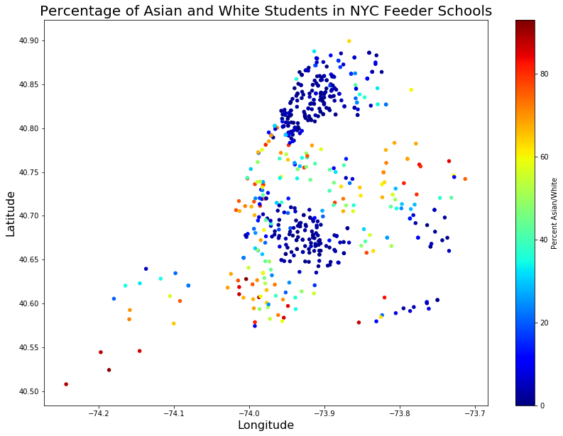

```python
fig, ax = plt.subplots(figsize=(14,10))
merged.plot(kind = 'scatter', x = 'Longitude', y = 'Latitude', c = 'Percent Asian/White', colormap = 'jet', ax=ax) #colors based on racial makeup
plt.xlabel('Longitude',fontsize=16)
plt.ylabel('Latitude',fontsize=16)
plt.title('Percentage of Asian and White Students in NYC Feeder Schools',fontsize=20)
```

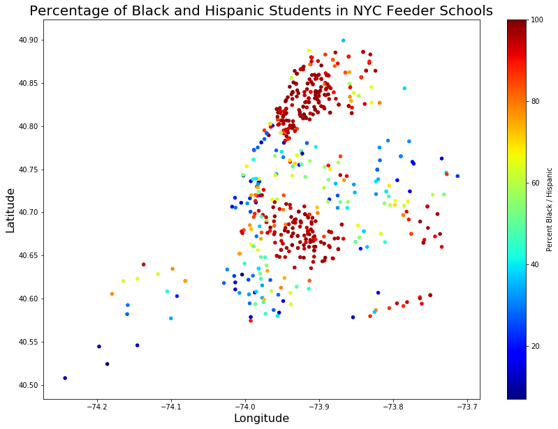

```python
fig, ax = plt.subplots(figsize=(14,10))

merged.plot(kind = 'scatter', x = 'Longitude', y = 'Latitude', c = 'Percent Black / Hispanic', colormap = 'jet', ax=ax) #colors based on racial makeup
plt.xlabel('Longitude',fontsize=16)
plt.ylabel('Latitude',fontsize=16)
plt.title('Percentage of Black and Hispanic Students in NYC Feeder Schools',fontsize=20)
```

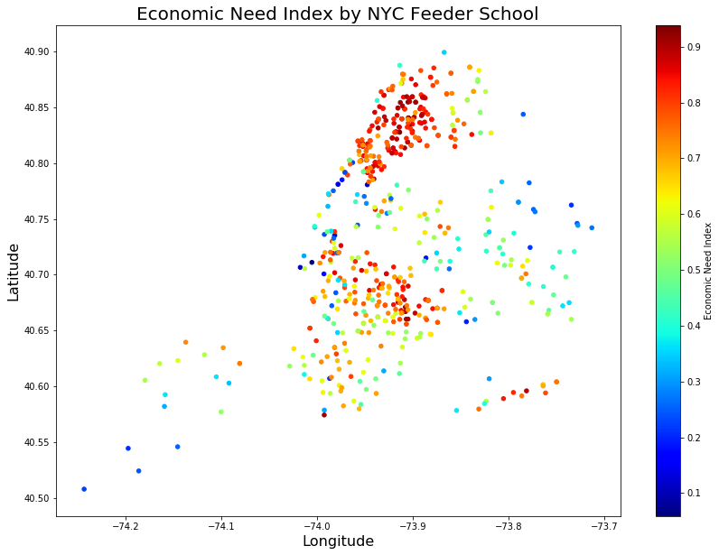

```python
fig, ax = plt.subplots(figsize=(14,10))

merged.plot(kind = 'scatter', x = 'Longitude', y = 'Latitude', c = 'Economic Need Index', colormap = 'jet', ax=ax) #colors based on racial makeup
plt.xlabel('Longitude',fontsize=16)
plt.ylabel('Latitude',fontsize=16)
plt.title('Economic Need Index by NYC Feeder School',fontsize=20)
plt.figure(figsize=(14, 10))
```

```python
#Let's dive a bit deeper. Let's analyze the racial makeup by 'City', as defined in the original PASSNYC schools dataset.

grouped = merged[['City','Percent Asian','Percent Black','Percent Hispanic','Percent White']].groupby(['City'],as_index=False)
g=grouped.agg(np.mean) #Averaging racial makeup of feeder schools, by city.
g
```

|  | City | Percent Asian | Percent Black | Percent Hispanic | Percent White |
| --- | --- | --- | --- | --- | --- |
| 0 | ARVERNE | 2.500000 | 70.500000 | 21.000000 | 2.500000 |
| 1 | ASTORIA | 28.500000 | 5.000000 | 33.750000 | 28.750000 |
| 2 | BAYSIDE | 53.666667 | 4.666667 | 17.000000 | 24.000000 |
| 3 | BELLEROSE | 26.000000 | 44.500000 | 18.500000 | 9.000000 |
| 4 | BROAD CHANNEL | 0.000000 | 2.000000 | 15.000000 | 83.000000 |
| 5 | BRONX | 3.360544 | 29.510204 | 62.585034 | 3.496599 |
| 6 | BROOKLYN | 8.322751 | 50.634921 | 28.603175 | 10.788360 |
| 7 | CAMBRIA HEIGHTS | 1.000000 | 95.000000 | 2.000000 | 1.000000 |
| 8 | CORONA | 6.000000 | 3.000000 | 89.000000 | 1.000000 |
| 9 | EAST ELMHURST | 13.000000 | 11.500000 | 61.000000 | 14.500000 |
| 10 | ELMHURST | 31.750000 | 4.000000 | 61.500000 | 2.250000 |
| 11 | FAR ROCKAWAY | 3.428571 | 61.571429 | 31.428571 | 2.571429 |
| 12 | FLORAL PARK | 62.000000 | 10.000000 | 13.000000 | 13.000000 |
| 13 | FLUSHING | 47.076923 | 10.846154 | 24.153846 | 16.769231 |
| 14 | FOREST HILLS | 33.000000 | 7.000000 | 28.000000 | 29.000000 |
| 15 | GLENDALE | 15.000000 | 1.000000 | 35.000000 | 47.000000 |
| 16 | HOLLIS | 27.000000 | 39.000000 | 28.000000 | 2.000000 |
| 17 | HOWARD BEACH | 5.666667 | 4.333333 | 31.666667 | 57.333333 |
| 18 | JACKSON HEIGHTS | 21.000000 | 3.333333 | 67.666667 | 7.000000 |
| 19 | JAMAICA | 20.428571 | 48.785714 | 18.285714 | 6.785714 |
| 20 | LITTLE NECK | 62.000000 | 3.000000 | 12.000000 | 23.000000 |
| 21 | LONG ISLAND CITY | 22.333333 | 11.416667 | 44.750000 | 19.416667 |
| 22 | MASPETH | 27.000000 | 1.000000 | 59.000000 | 13.000000 |
| 23 | MIDDLE VILLAGE | 6.750000 | 1.000000 | 37.750000 | 53.750000 |
| 24 | NEW YORK | 7.872000 | 29.008000 | 47.728000 | 12.928000 |
| 25 | OZONE PARK | 38.666667 | 6.000000 | 47.000000 | 4.333333 |
| 26 | QUEENS VILLAGE | 35.500000 | 32.500000 | 24.500000 | 4.500000 |
| 27 | REGO PARK | 20.500000 | 14.000000 | 31.000000 | 30.500000 |
| 28 | RIDGEWOOD | 10.000000 | 2.000000 | 73.500000 | 14.000000 |
| 29 | ROCKAWAY BEACH | 3.000000 | 53.000000 | 33.000000 | 6.000000 |
| 30 | ROCKAWAY PARK | 7.750000 | 31.500000 | 22.250000 | 37.250000 |
| 31 | ROOSEVELT ISLAND | 29.000000 | 16.000000 | 14.000000 | 36.000000 |
| 32 | ROSEDALE | 2.000000 | 90.500000 | 5.000000 | 1.000000 |
| 33 | SAINT ALBANS | 2.333333 | 88.666667 | 7.000000 | 0.666667 |
| 34 | SOUTH OZONE PARK | 32.333333 | 35.333333 | 19.666667 | 1.666667 |
| 35 | SPRINGFIELD GARDENS | 1.600000 | 88.800000 | 5.600000 | 1.200000 |
| 36 | STATEN ISLAND | 8.588235 | 18.117647 | 28.882353 | 43.294118 |
| 37 | WHITESTONE | 35.000000 | 2.000000 | 29.000000 | 33.000000 |
| 38 | WOODSIDE | 40.000000 | 1.000000 | 53.000000 | 5.000000 |

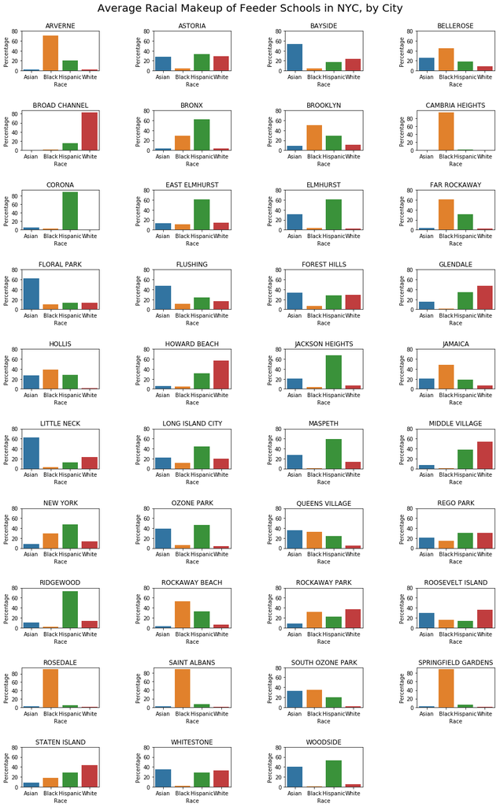

```python
plt.figure(figsize=(16,24))
for i in range(len(g)):
    plt.subplot(10, 4, i+1)
    a=[g.loc[i]['Percent Asian'],g.loc[i]['Percent Black'],g.loc[i]['Percent Hispanic'],g.loc[i]['Percent White']]
    ax = sns.barplot(['Asian','Black','Hispanic','White'],a)
    ax.grid(False)
    plt.yticks(np.arange(0,100,20))
    plt.subplots_adjust(wspace =0.7,hspace = 1)
    plt.title(g.loc[i]['City'])
    plt.xlabel('Race')
    plt.ylabel('Percentage')
    plt.subplots_adjust(top= 0.95)
    plt.suptitle('Average Racial Makeup of Feeder Schools in NYC, by City',fontsize=20)
```

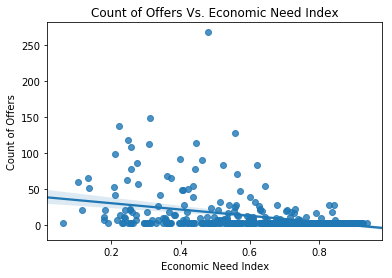

```python
sns.regplot(x='Economic Need Index', y='Count of Offers', data=merged) #Regression plot of ENI and Count of Offers
plt.title('Count of Offers Vs. Economic Need Index')
```

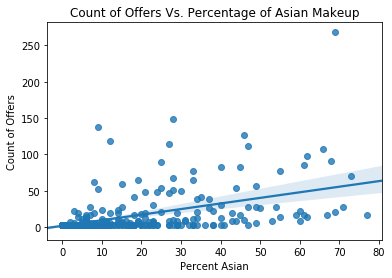

```python
sns.regplot(x='Percent Asian', y='Count of Offers', data=merged) #Regression plot of Percent Asian and Count of Offers
plt.title('Count of Offers Vs. Percentage of Asian Makeup')
```

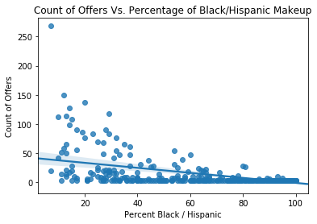

```python
sns.regplot(x='Percent Black / Hispanic', y='Count of Offers', data=merged) #Regression plot of percent Black/Hispanic and Count of Offers
plt.title('Count of Offers Vs. Percentage of Black/Hispanic Makeup')
```

```python
merged2 = merged[['Count of Offers','District','Community School?','Economic Need Index','School Income Estimate',
                 'Average ELA Proficiency','Average Math Proficiency','Percent ELL','Student Attendance Rate','Percent of Students Chronically Absent','Supportive Environment %',
                 'Collaborative Teachers %','Trust %','Effective School Leadership %','Strong Family-Community Ties %','Percent Asian','Percent Black','Percent Hispanic','Percent White']]
merged2.head() #creating new df with quantitative variables of interest
```

|  | Count of Offers | District | Community School? | Economic Need Index | School Income Estimate | Average ELA Proficiency | Average Math Proficiency | Percent ELL | Student Attendance Rate | Percent of Students Chronically Absent | Supportive Environment % | Collaborative Teachers % | Trust % | Effective School Leadership % | Strong Family-Community Ties % | Percent Asian | Percent Black | Percent Hispanic | Percent White |
| --- | --- | --- | --- | --- | --- | --- | --- | --- | --- | --- | --- | --- | --- | --- | --- | --- | --- | --- | --- |
| 0 | 3.0 | 1.0 | No | 0.860 | 31454.00 | 2.48 | 2.47 | 7.0 | 92.0 | 28.0 | 82.0 | 78.0 | 88.0 | 73.0 | 89.0 | 5.0 | 29.0 | 63.0 | 4.0 |
| 1 | 3.0 | 1.0 | No | 0.849 | 34889.24 | 2.21 | 2.27 | 14.0 | 93.0 | 27.0 | 85.0 | 91.0 | 93.0 | 87.0 | 83.0 | 5.0 | 13.0 | 78.0 | 3.0 |
| 2 | 28.0 | 1.0 | No | 0.559 | 40809.90 | 3.24 | 3.63 | 17.0 | 98.0 | 2.0 | 91.0 | 81.0 | 85.0 | 67.0 | 83.0 | 71.0 | 4.0 | 12.0 | 9.0 |
| 3 | 3.0 | 1.0 | Yes | 0.917 | 27881.59 | 2.17 | 2.32 | 16.0 | 91.0 | 37.0 | 99.0 | 100.0 | 99.0 | 99.0 | 92.0 | 2.0 | 30.0 | 64.0 | 4.0 |
| 4 | 3.0 | 1.0 | No | 0.791 | 75459.24 | 2.29 | 2.00 | 6.0 | 90.0 | 35.0 | 81.0 | 78.0 | 87.0 | 80.0 | 74.0 | 8.0 | 29.0 | 55.0 | 4.0 |

```python
merged2.corr() #correlation matrix
```

|  | Count of Offers | District | Economic Need Index | School Income Estimate | Average ELA Proficiency | Average Math Proficiency | Percent ELL | Student Attendance Rate | Percent of Students Chronically Absent | Supportive Environment % | Collaborative Teachers % | Trust % | Effective School Leadership % | Strong Family-Community Ties % | Percent Asian | Percent Black | Percent Hispanic | Percent White |
| --- | --- | --- | --- | --- | --- | --- | --- | --- | --- | --- | --- | --- | --- | --- | --- | --- | --- | --- |
| Count of Offers | 1.000000 | 0.096312 | -0.394384 | 0.236485 | 0.517210 | 0.484289 | -0.128599 | 0.105223 | -0.250785 | 0.073720 | 0.035638 | 0.030081 | 0.036645 | -0.200469 | 0.531534 | -0.288736 | -0.238064 | 0.358221 |
| District | 0.096312 | 1.000000 | -0.297890 | 0.215991 | 0.085730 | 0.069601 | -0.115446 | 0.147407 | -0.180946 | 0.002393 | 0.030137 | -0.023928 | -0.024538 | -0.193537 | 0.273604 | 0.057653 | -0.327291 | 0.158310 |
| Economic Need Index | -0.394384 | -0.297890 | 1.000000 | -0.787248 | -0.771161 | -0.666517 | 0.475384 | -0.180653 | 0.508080 | -0.120657 | -0.156023 | -0.078266 | -0.145433 | -0.029160 | -0.427540 | 0.197639 | 0.581055 | -0.755359 |
| School Income Estimate | 0.236485 | 0.215991 | -0.787248 | 1.000000 | 0.512835 | 0.402176 | -0.308807 | 0.137718 | -0.346657 | 0.079393 | 0.117979 | 0.046780 | 0.097269 | 0.024345 | 0.321086 | -0.203144 | -0.431903 | 0.641201 |
| Average ELA Proficiency | 0.517210 | 0.085730 | -0.771161 | 0.512835 | 1.000000 | 0.934783 | -0.474873 | -0.012803 | -0.418785 | 0.279195 | 0.256317 | 0.186278 | 0.225208 | 0.097077 | 0.475641 | -0.281935 | -0.418784 | 0.624301 |
| Average Math Proficiency | 0.484289 | 0.069601 | -0.666517 | 0.402176 | 0.934783 | 1.000000 | -0.386935 | -0.083767 | -0.392921 | 0.284144 | 0.253450 | 0.192164 | 0.221505 | 0.141021 | 0.485610 | -0.270290 | -0.368451 | 0.531515 |
| Percent ELL | -0.128599 | -0.115446 | 0.475384 | -0.308807 | -0.474873 | -0.386935 | 1.000000 | 0.000215 | 0.161543 | 0.023804 | -0.116793 | -0.031294 | -0.145018 | -0.091610 | 0.002197 | -0.380234 | 0.603440 | -0.232736 |
| Student Attendance Rate | 0.105223 | 0.147407 | -0.180653 | 0.137718 | -0.012803 | -0.083767 | 0.000215 | 1.000000 | -0.781512 | -0.050697 | -0.031603 | -0.031289 | -0.008975 | -0.149686 | 0.161232 | -0.167589 | -0.005809 | 0.142057 |
| Percent of Students Chronically Absent | -0.250785 | -0.180946 | 0.508080 | -0.346657 | -0.418785 | -0.392921 | 0.161543 | -0.781512 | 1.000000 | -0.069114 | -0.108383 | -0.075712 | -0.127087 | 0.040541 | -0.336351 | 0.237097 | 0.169850 | -0.332374 |
| Supportive Environment % | 0.073720 | 0.002393 | -0.120657 | 0.079393 | 0.279195 | 0.284144 | 0.023804 | -0.050697 | -0.069114 | 1.000000 | 0.604443 | 0.738080 | 0.506635 | 0.555982 | 0.059544 | -0.166539 | 0.010995 | 0.191995 |
| Collaborative Teachers % | 0.035638 | 0.030137 | -0.156023 | 0.117979 | 0.256317 | 0.253450 | -0.116793 | -0.031603 | -0.108383 | 0.604443 | 1.000000 | 0.880255 | 0.913895 | 0.486428 | 0.020748 | -0.054384 | -0.087585 | 0.189758 |
| Trust % | 0.030081 | -0.023928 | -0.078266 | 0.046780 | 0.186278 | 0.192164 | -0.031294 | -0.031289 | -0.075712 | 0.738080 | 0.880255 | 1.000000 | 0.852695 | 0.588936 | -0.023126 | -0.074524 | -0.005309 | 0.138535 |
| Effective School Leadership % | 0.036645 | -0.024538 | -0.145433 | 0.097269 | 0.225208 | 0.221505 | -0.145018 | -0.008975 | -0.127087 | 0.506635 | 0.913895 | 0.852695 | 1.000000 | 0.460466 | -0.021082 | 0.019565 | -0.118374 | 0.148558 |
| Strong Family-Community Ties % | -0.200469 | -0.193537 | -0.029160 | 0.024345 | 0.097077 | 0.141021 | -0.091610 | -0.149686 | 0.040541 | 0.555982 | 0.486428 | 0.588936 | 0.460466 | 1.000000 | -0.313069 | 0.201240 | -0.068106 | 0.014050 |
| Percent Asian | 0.531534 | 0.273604 | -0.427540 | 0.321086 | 0.475641 | 0.485610 | 0.002197 | 0.161232 | -0.336351 | 0.059544 | 0.020748 | -0.023126 | -0.021082 | -0.313069 | 1.000000 | -0.433907 | -0.291777 | 0.275522 |
| Percent Black | -0.288736 | 0.057653 | 0.197639 | -0.203144 | -0.281935 | -0.270290 | -0.380234 | -0.167589 | 0.237097 | -0.166539 | -0.054384 | -0.074524 | 0.019565 | 0.201240 | -0.433907 | 1.000000 | -0.523416 | -0.486507 |
| Percent Hispanic | -0.238064 | -0.327291 | 0.581055 | -0.431903 | -0.418784 | -0.368451 | 0.603440 | -0.005809 | 0.169850 | 0.010995 | -0.087585 | -0.005309 | -0.118374 | -0.068106 | -0.291777 | -0.523416 | 1.000000 | -0.328902 |
| Percent White | 0.358221 | 0.158310 | -0.755359 | 0.641201 | 0.624301 | 0.531515 | -0.232736 | 0.142057 | -0.332374 | 0.191995 | 0.189758 | 0.138535 | 0.148558 | 0.014050 | 0.275522 | -0.486507 | -0.328902 | 1.000000 |

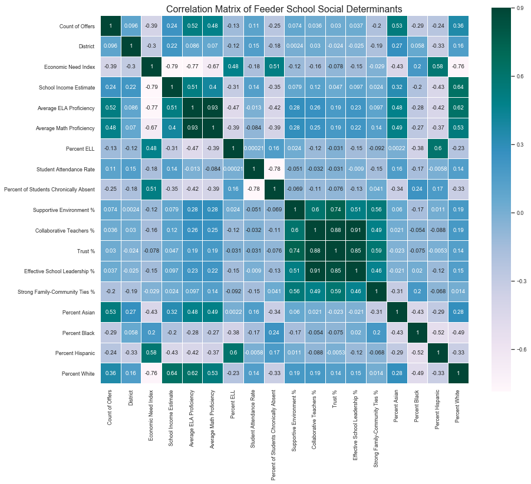

```python
#Correlation Matrix
corr = merged2.corr()
corr = (corr)

sns.set(font_scale= 0.8)
plt.figure(figsize=(14, 12))
sns.heatmap(corr,
            vmax=.9,
            linewidths=0.01,
            square=True,
            annot=True,
            cmap='PuBuGn',
            linecolor='white')
plt.title('Correlation Matrix of Feeder School Social Determinants', fontsize = 16)
```

```python
#K-Means Clustering

#There is a high correlation between ELA proficiency, math proficiency, and count of offers. We will include both ELA and math proficiency in our k-means.
```

```python
merged3 = merged2[['Average ELA Proficiency','Average Math Proficiency']]

X = merged3
```

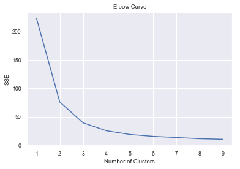

```python
n_clusters=10
sse=[]
for i in range(1,n_clusters):
    kmean=KMeans(i)
    kmean.fit(X)
    merged2['clusters'] = kmean.labels_
    sse.append(kmean.inertia_)

plt.plot(range(1,10),sse)
plt.grid(True)
plt.title('Elbow Curve')
plt.ylabel('SSE')
plt.xlabel('Number of Clusters')
#We will choose 4 clusters
```

```python
kmean = KMeans(4)
cluster_labels = kmean.fit_predict(np.array(X))
kmean.fit(X)
merged['clusters'] = kmean.labels_ #labeling kmeans clusters
```